# Введение в Git

## Системы контроля версия и почему среди них популярен Git

### Что такое системы контроля (СКВ) версий и с чем их едят?

CКВ -- это система, которая регистрирует все изменения в файлах, а в дальнейшем позволяет вернуться к их более ранним версиям и определить, кем и когда были сделаны конкретные изменения.

### Мотивация в использовании СКВ

- необходимость отката
- просмотр истории эволюции кода из IDE
- защита от потери сорцов
- простой деплой между серверами
- ветвление версий
- руководство разработкой

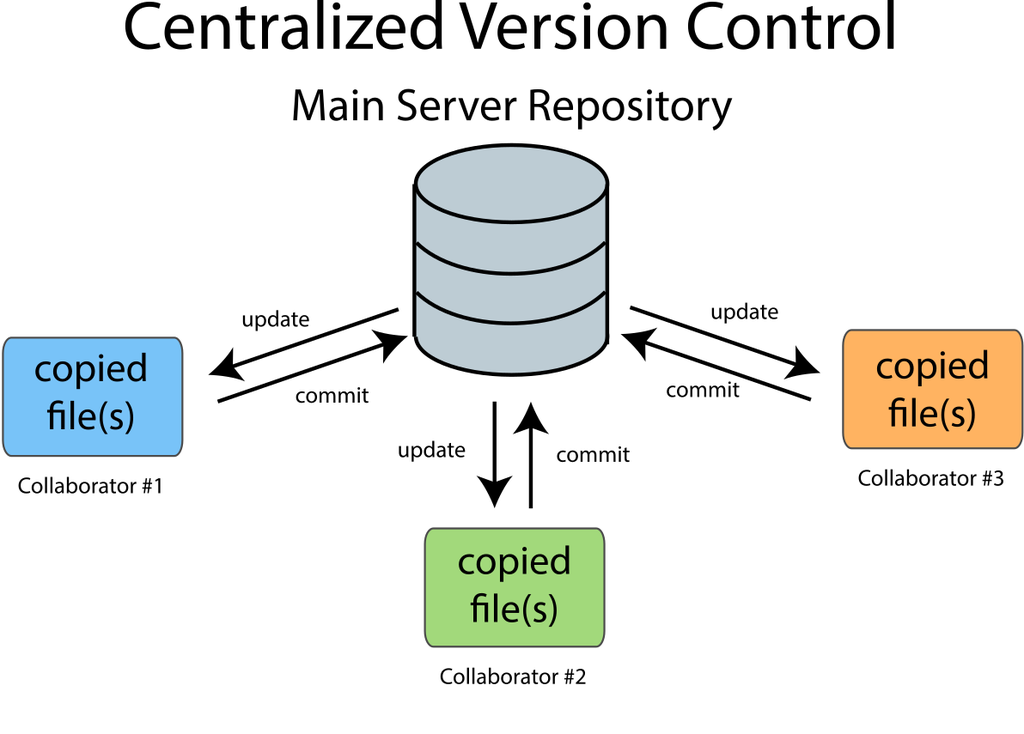

```python
Image("images/vcs-centralized.png", width=600)
```

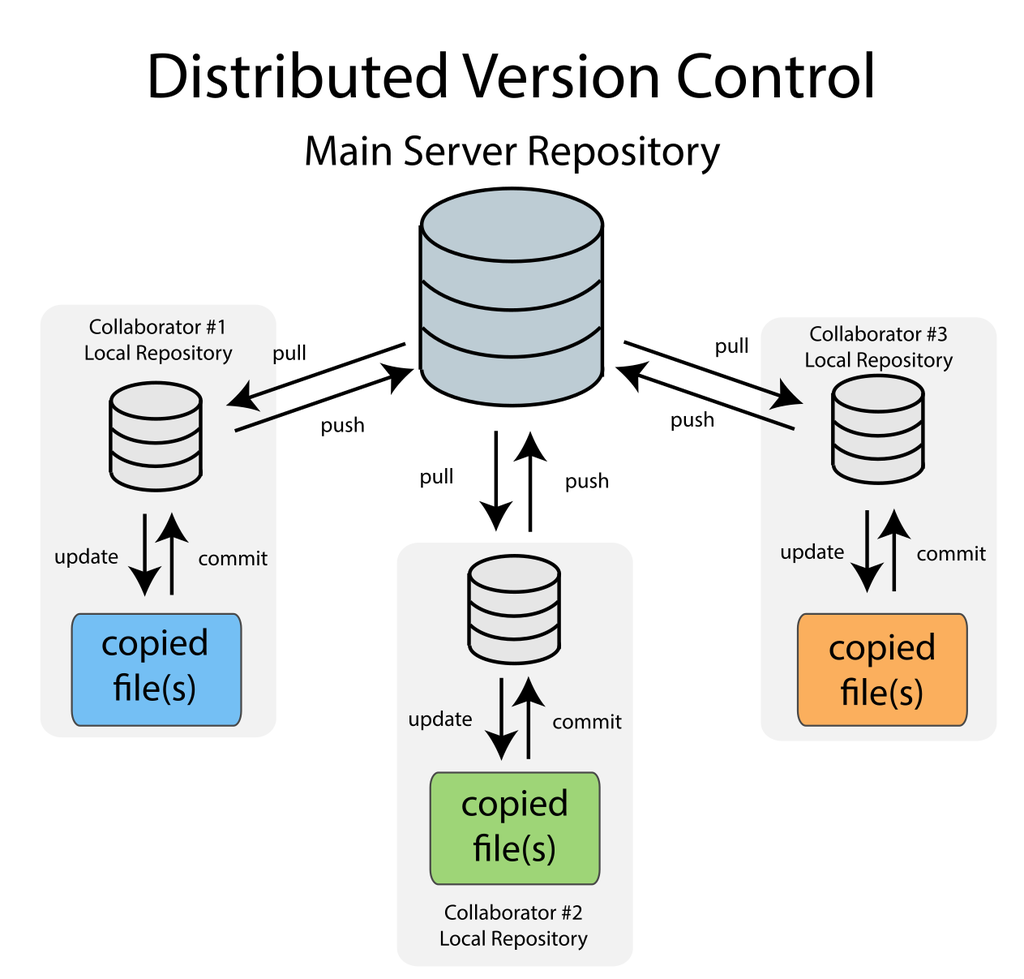

```python
Image("images/vcs-distributed.png", width=600)
```

### Обзор популряных систем контроля версий

[figure not shown]

```python
Image("images/VCS-rating.png")
```

### Почему Git?

Все плюсы распределенной СКВ:

- GIT сохраняет локально полную копию репозитория.
- Не нужно иметь доступа к серверу, чтобы сохранить в системе контроля версий измененный файл

Git vs SVN:

- Git хранит «слепки» файлов в сжатом виде.
- Решено большое количество проблем со слиянием веток, которыми богат Subversion

С самого начала Git боролся за популярность с Mercurial (Hg), который в некоторых аспектах проще, но в итоге вырвался в лидеры Git.

Немаловажную роль во всеобщей популярности Git’a в мире CVS сыграл ресурс GitHub, на котором размещены тысячи репозиториев на различных языках.

### GitHub

[figure not shown]

```python
Image("images/github_projects.png")
```

### Другие web-cервисы, использующие Git

[figure not shown]

```python
Image("images/github_gitlab_bitbucket.jpeg")
```

## Как устроен Git?

```python
Image("images/git_deltas.png")
```

[output not shown]

```python
Image("images/git_versions.png")
```

[output not shown]

**Номер ревизии** (он же SHA-1 хеш) -- контрольная сумма, которая вичляется при сохранении файлов в Git-репозитории.

Минусы -- номера ревизий идут не порядку.

Скачать репозиторий:

```python
git clone http://github.com/example/example.git
cd example
```

Добавить измения в локальную копию (коммит):

```python
git add file
git add *
git commit -m "Commit omment"
```

Отправить изменения на сервер (запушить):

```python
git push origin master
```

Получить обновления:

```python
git pull
```

Информация:

```python
git status
git log
git diff
```

## Основы ветвления в Git

### Что такое ветвление и зачем оно нужно?

Ветвеление позволяет изолированно работать над задачами в проекте.

По умолчанию разработка ведется в ветке master.

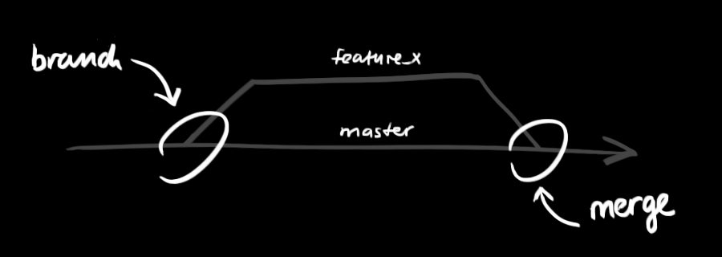

```python
Image("images/branches.png")
```

### Ветвление, пример использованияи

- Поработаем над проектом.
- Создадим ветку для работы над новой задачей.
- Выполним некоторую работу на этой ветке.
- На этом этапе вам поступит звонок о том, что сейчас критична другая проблема, и её надо срочно решить. Мы сделаем следующее:
- Вернёмся на ветку для версии в производстве.
- Создадим ветку для исправления ошибки.
- После тестирования ветки с исправлением сольём её обратно и отправим в продакшн.
- Вернёмся к своей исходной задаче и продолжим работать над ней.

Без веток практически немыслима совместная разработка -- иначе как добавлять и тестировать новые "фичи" в проект, не ломая при этом основной код?!

### Команды для работы с ветками

Создать новую ветку и перейти в нее:

```python
git chekcout -b mybranch
```

Просмотреть список веток:

```python
git branch
```

Залить изменения в ветку:

```python
git push origin mybranch
```

Перейти в другую ветку (мастер):

```python
git checkout master
```

Слить ветку с мастером:

```python
git merge mybranch
```

Удалить ветку:

```python
git branch -D mybranch
```

Вспомогательное:

```python
git branch -v
git branch --merged
git branch --no-merged
```

### Тэги

Для релизов программного обеспечения принято использовать не ветки, а тэги -- это "снимок" состояния ветки (обычно мастера) в конкретный момент времени.

```python
git tag 1.0.0 1b2e1d63ff
```

В тэг нельзя внести измеения.

## GitHub

[figure not shown]

```python
Image("images/github_screen.png")
```

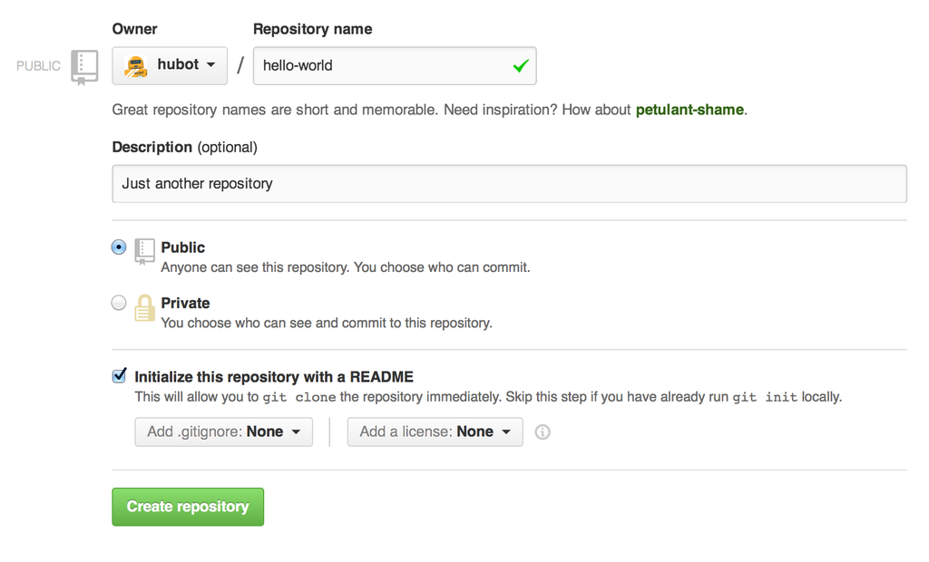

```python
Image("images/github_create.png", width=800)
```

[figure not shown]

```python
Image("images/github_fork.png")
```

Настройка подкачки обновлений из исходного репозитория:

```python
git remote add upstream https://github.com/example/example
```

upstream -- имя, по которому доступен удаленный репозиторий.

Получить обновления:

```python
git pull upstream
```

## Tortoise Git

[figure not shown]

```python
Image("images/tortoise-log.png")
```

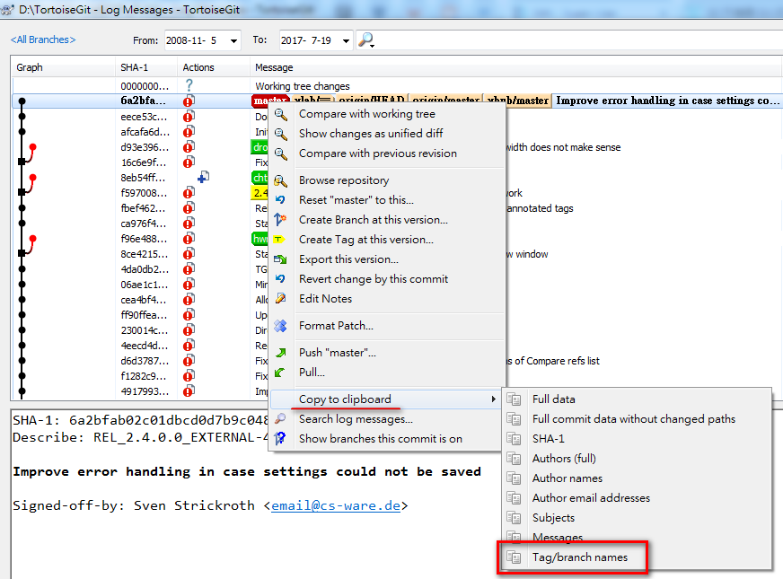

```python
Image("images/tortoise.png")
```

## Ccылки

**[Ой, блин, гит!](https://ru.hexlet.io/blog/posts/oh-shit-git)**

**«Волшебство git»**

«Удачная модель ветвления для git» — перевод хорошей англоязычной статьи

Интерактивный курс по работе с git из консоли

«Почему git» + обсуждение

«Git для переходящих с SVN» + обсуждение

«Командная работа в git» + обсуждение

Русский перевод книги «Pro Git» (переведено не до конца)

Инструкция-шпаргалка для начинающих

Цикл постов «внутренности git»

Линус Торвальдс о git

## Материалы семинара

https://github.com/asmagina1995/python-workshops/blob/master/git